# HSAM: Power Go-NoGo

Author

Lorenzo Atzeni

Scegliamo i parametri:

```r
b0 <- -0.7
b1 <- 0.183
b2 <- 0
b3 <- 0.11
```

B0=-0.7 –> (exp(−0.7))= 500 ms (RT gruppo di controllo nella condizione SCONOSCIUTO)

B1=0.183 ->(exp(0.183)) =1.2 incremento RT 20% stimoli associati al sè.

B2–>nullo-> No differenze tra gruppi in RT nella condizione SCONOSCIUTO

B3=0.11->(exp(0.11)) -> 1.11->per gli HSAM la condizione TU determina un aumento ulteriore dei tempi di reazione dell’11% rispetto a quanto osservato nei controlli, circa 55ms.

```r
library(MASS)
# matrice di covarianza con correlazione 0.25
Sigma <- matrix(c(0.01, 0.0025,
                  0.0025, 0.01), nrow = 2)
rand_eff <- mvrnorm(n = N, mu = c(0, 0), Sigma = Sigma)
b0i <- rand_eff[, 1]
b1i <- rand_eff[, 2]

df$b0i <- b0i[df$id]
df$b1i <- b1i[df$id]
```

Calcoliamo rate usando la formula inversa shape=mu/rate

```r
shape=17
log_mu <- with(df, b0 + b1*I + b2*G + b3*I*G +b0i + b1i * I)
mu <- exp(log_mu)
rate<-mu/shape

df$y  <- rgamma(nrow(df), shape = shape, scale = mu / shape)
```

```
   Min. 1st Qu.  Median    Mean 3rd Qu.    Max.
 0.1373  0.4446  0.5445  0.5679  0.6666  1.6172
```

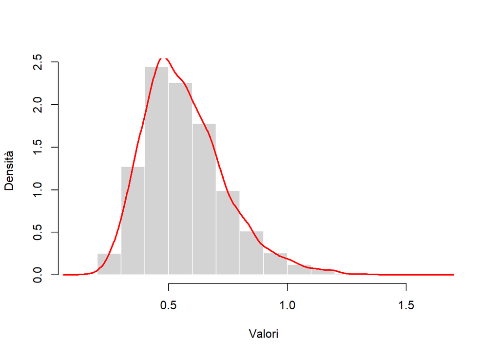

Facciamo una prova e fittiamo il modello con n=10000 per vedere se stima bene i parametri.

```
 Family: Gamma  ( log )
Formula:          y ~ I * G + (1 + I | id)
Data: df

       AIC        BIC     logLik  -2*log(L)   df.resid
-1147348.5 -1147254.0   573682.2 -1147364.5     999992

Random effects:

Conditional model:
 Groups Name        Variance Std.Dev. Corr
 id     (Intercept) 0.009881 0.09940
        I           0.009863 0.09931  0.23
Number of obs: 1000000, groups:  id, 10000

Dispersion estimate for Gamma family (sigma^2): 0.059

Conditional model:
             Estimate Std. Error z value Pr(>|z|)
(Intercept) -0.701234   0.001487  -471.5   <2e-16 ***
I            0.184172   0.001564   117.8   <2e-16 ***
G            0.001298   0.002103     0.6    0.537
I:G          0.112797   0.002211    51.0   <2e-16 ***
---
Signif. codes:  0 '***' 0.001 '**' 0.01 '*' 0.05 '.' 0.1 ' ' 1
```

Con `n = 10000` il modello riesce a stimare correttamente i parametri. Passiamo ora alla scelta delle prior.

Poiché in letteratura esiste un solo studio simile al nostro (*Dalmaso et al., 2019*), è opportuno adottare **prior scettiche**, cioè centrate sullo zero e con varianza ridotta, come suggerito da *Kruschke e Liddell (2018)*. Tuttavia, con campioni più piccoli, questo approccio rischia di spingere la stima di β₃ costantemente verso lo zero, limitando l’inferenza.

Per ovviare a questo problema, come già fatto nell’articolo preparato per il GIP, è stata scelta una **distribuzione t di Student con 3 gradi di libertà**, media zero e deviazione standard pari a **0.08**. Questa specifica consente di rappresentare un’ampia gamma di valori plausibili per l’effetto, pur mantenendo una maggiore densità in prossimità dello zero.

In particolare, questa prior **ammette che l’interazione tra identità e gruppo possa produrre una variazione del tempo di reazione compresa tra circa −30% e +40%**, ma conserva un atteggiamento cauto rispetto all’evidenza. Include comodamente anche il valore simulato come reale, che corrisponde a un effetto del **+11%**. In questo modo, si ottiene una stima credibile che incorpora l’incertezza iniziale **senza compromettere l’identificabilità del modello**.

```r
library(brms)

#priorB3<-a prior ammette che l’effetto differenziale possa andare da circa –30 % a +40 %, con maggior densità vicino a 0.
#Contiene comodamente il valore vero simulato (+11 %).
  myPRIORS <- c(
    set_prior("student_t(3, 0, 1)", class = "Intercept"),

  set_prior( paste0("student_t(3, 0, .08)"), class = "b",
             coef = "I"),
  set_prior( paste0("student_t(3, 0, .08)"), class = "b",
             coef = "G"),
  #set_prior( paste0("student_t(3, 0, .0055)"), class = "b",
  set_prior( paste0("student_t(3, 0, .08)"), class = "b",
             coef = "I:G"),
  set_prior( paste0("student_t(3, 0, 1)"), class = "sd" ),
  set_prior(paste0("gamma(", shape, ", 34)"), class = "shape"))
```

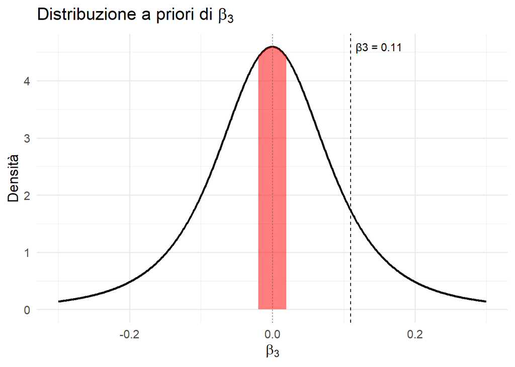

la probabilità che B3 cada nell intervallo nullo è di:

```
[1] 0.1795297
```

mentre che sia maggiore uguale a .11 è di:

```
[1] 0.131413
```

**Algoritmo calcolo power:** La potenza viene calcolata come il rapporto tra il numero di volte in cui l’intervallo di credibilità del parametro b3 non include lo zero sul totale numero di iterazioni.

```r
BE <- c(-0.7, 0.183, 0, 0.11)

LEVEL <- .90

PROBS <- c((1 - LEVEL) / 2, 1 - (1 - LEVEL) / 2)

#sample_size <- c(20, 50, 70, 100, 120, 150)
sample_size <- c(20, 50, 70, 100, 120)
n_sim <- 100
n_trial <- 100
shape <- 17
Sigma <- matrix(c(0.01, 0.0025, 0.0025, 0.01), 2, 2)
SCENARIO <- "go_no_go"
datadir <- "./"  # o dove vuoi salvare i file
LETTER <- "A"

form <- bf(y ~ I * G + (1 + I | id), family = Gamma(link = "log"))


# Funzione per simulare i dati
for (n in sample_size) {
  EXP2 <- OBS <- NULL
  for (b in 1:n_sim) {
    cat(paste0("n = ", n, " (", b, "/", n_sim, ")\n"))

    df <- expand.grid(trial = 1:n_trial, id = 1:n)
    df$G <- ifelse(df$id <= n / 2, 0, 1)
    df$I <- ifelse(df$trial <= (n_trial / 2), 0, 1)

    rand_eff <- mvrnorm(n = n, mu = c(0, 0), Sigma = Sigma)
    b0i <- rand_eff[, 1]
    b1i <- rand_eff[, 2]

    df$b0i <- b0i[df$id]
    df$b1i <- b1i[df$id]

    log_mu <- with(df, BE[1] + BE[2]*I + BE[3]*G + BE[4]*I*G + b0i + b1i * I)
    mu <- exp(log_mu)
    df$y <- rgamma(nrow(df), shape = shape, scale = mu / shape)

    if (b == 1) {
      base_fit <- brm(formula = form, data = df, prior = myPRIORS,
                      chains = 4, iter = 4000, warmup = 1000,
                      control = list(adapt_delta = 0.99),
                      cores = parallel::detectCores(), refresh = 0)
    }

    fit <- update(base_fit, newdata = df, recompile = FALSE, refresh = 0)

    converged <- all(rhat(fit) <= 1.05)

    est <- data.frame(fixef(fit, probs = PROBS))

    est$detected <- FALSE  # inizializza tutta la colonna
    ci_b3 <- est["I:G", c("Q5", "Q95")]  #CI_low, CI_high
    est["I:G", "detected"] <- (ci_b3[1] > 0 | ci_b3[2] < 0) #CI_low>0  CI_high<0
    est$converged <- converged
    est$par <- rownames(est)
    est$n <- n
    est$iter <- b
    est$scenario <- SCENARIO

    EXP2 <- rbind(EXP2, est)
  }

  save(EXP2, file = paste0(datadir, "power_sim_", SCENARIO, "_n", n, LETTER, ".rda"))
}


EXP2_b3 <- subset(EXP2, par == "I:G"& converged == TRUE)
power_by_n <- aggregate(detected ~ n, data = EXP2_b3, FUN = mean)
print(power_by_n)
```

[output not shown]